# More advanced matters

**Note.** We have a working script prepared for you to put your answers in, called “Working Script Practical 2.Rmd.

This is the second practical, we will dive into more advanced matters: model selection, subject specific parameters, model diagnostics, and model fit. Note that we cover a lot of ground here, most likely too much to finish within this practical. All parts are modular, so feel free to work on the aspects that are most relevant to you.

We continue with the same dataset: the open access dataset from Rowland and Wenzel (2020), using the subset of the affective experiences *happy*, *relaxed*, *anxious*, and *depressed*, measured six times a day for 40 days in total.

The answers to the practicals are available in the `*_answers.html` files.

In all practicals in this workshop, we make use of the `mHMMbayes` package, version 1.1.0. We again load the package:

```r
library(mHMMbayes)
```

In this practical, we will also use the following packages:

```r
# install.packages("coda")
library(ggplot2) # for plotting
library(ggmHMM) # plotting mHMM objects
library(coda) # for assessing convergence

source('./helpers.R') # Some helper functions
```

## Subject specific parameters

In this section, we obtain and inspect the subject specific parameters.

### Emission distribution

We first obtain the subject specific emission distribution parameters from the model output, and save the subject specific parameters in a new object. When focusing on the emission distribution parameters, the function `obtain_emiss()` can be used to obtain the subject specific emission distribution parameters, by setting the input argument `level="subject"`. Note that the default of `level` is `"group"`, so when left unspecified, the function `obtain_emiss()` will return the group level emission distribution parameters, as we have seen in the first practical.

**Exercise 1** Obtain the subject-specific emission distribution parameters using the function `obtain_emiss()` and set the input argument `level` to `"subject"`. Save the output in the object `emiss_subject`. Inspect the output.

```r
# obtaining and saving the subject specific transition probabilities
emiss_subject <- obtain_emiss(out_2st_emotion, level = "subject")
```

Again, to get an overview of how much the emission distribution parameters (e.g., the variable and state specific means) vary over subjects, it is helpful to plot the subject specific emission distribution parameters, for example by adding the subject specific parameters as dots to a group level barplot of the emission means. This can be done using the *ggmHMM* function `plot_emiss()`.

**Exercise 2** Plot (a subset of) the subject specific emission distribution means, using the function `plot_emiss()` from the *ggmHMM* package and investigate how much the means differ over subjects. Hint: both functions have the argument `subject`, which can be used to specify a vector of subjects to plot random effects for.

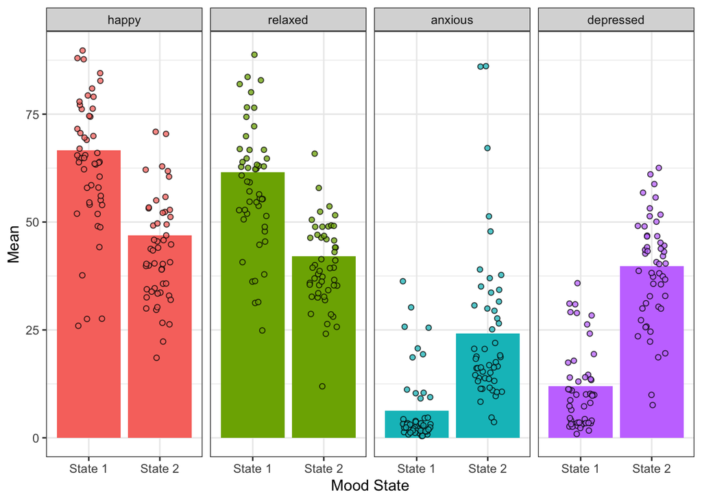

```r
# using ggmHMM package
plot_emiss(out_2st_emotion,
           subject_effects = TRUE,
           line = FALSE,
           subject = 1:50) # Only plot subset for cleaner figure
```

In addition, it is important to check that the states represent the same construct over subjects. In the current dataset, that would mean that for each subject, state 1 represents a ‘positive mood’ state, and state 2 represents a ‘negative mood’ state. For example, for the indicator *happy*, that would translate to the mean of state 1 being higher compared to state 2. Visually, this can be checked by connecting the subject specific means over the states within one indicator by lines and assessing whether many lines are crossing (they should not!).

**Exercise 3** Plot (a subset of) the subject specific emission distribution means connecting the subject specific means, and visually investigate whether the state 1 is a relatively positive state and state 2 a relatively negative state over subjects. Hint: this can be done by specifying `line = TRUE` in `plot_emiss()`.

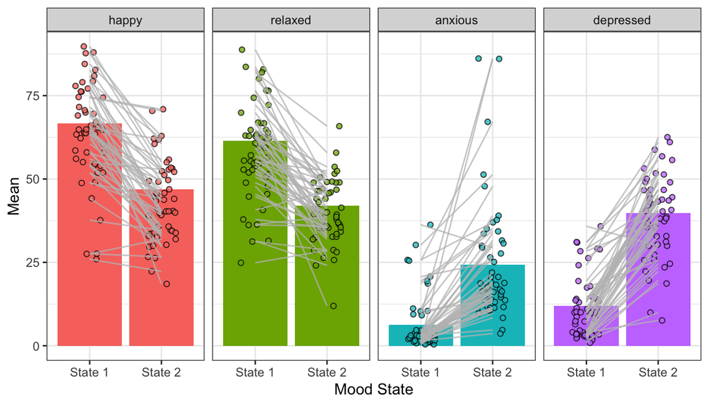

```r
## plot first 50 subjects to aid interpretability
plot_emiss(out_2st_emotion,
           subject_effects = TRUE,
           line = TRUE,
           subject = 1:50) # using ggmHMM function
```

### Transition probabilities gamma

First, we need to obtain the subject specific parameters for the emissions and the transition probabilities. Analogously to the emission parameters, the function `obtain_gamma()` can also be used to obtain the subject specific transition probabilities, by setting the input argument `level="subject"`. Again, the default of `level` is `"group"`, so when left unspecified, the function `obtain_gamma()` will return the group level transition probabilities.

**Exercise 4** Obtain the subject specific transition probabilities using the function `obtain_gamma()` and set the input argument `level` to `"subject"`. Save the output in the object `gamma_subject`. Inspect the output.

```r
# obtaining and saving the subject specific transition probabilities
gamma_subject <- obtain_gamma(out_2st_emotion, level = "subject")

# inspecting the output, restring the returned output to the first 10 subjects
gamma_subject[1:10]
```

```
## $`Subject 1`
##              To state 1 To state 2
## From state 1      0.598      0.402
## From state 2      0.368      0.632
##
## $`Subject 2`
##              To state 1 To state 2
## From state 1      0.737      0.263
## From state 2      0.147      0.853
##
## $`Subject 3`
##              To state 1 To state 2
## From state 1       0.96       0.04
## From state 2       0.40       0.60
##
## $`Subject 4`
##              To state 1 To state 2
## From state 1      0.716      0.284
## From state 2      0.282      0.718
##
## $`Subject 5`
##              To state 1 To state 2
## From state 1      0.922      0.078
## From state 2      0.493      0.507
##
## $`Subject 6`
##              To state 1 To state 2
## From state 1      0.767      0.233
## From state 2      0.361      0.639
##
## $`Subject 7`
##              To state 1 To state 2
## From state 1      0.438      0.562
## From state 2      0.141      0.859
##
## $`Subject 8`
##              To state 1 To state 2
## From state 1      0.948      0.052
## From state 2      0.232      0.768
##
## $`Subject 9`
##              To state 1 To state 2
## From state 1      0.615      0.385
## From state 2      0.215      0.785
##
## $`Subject 10`
##              To state 1 To state 2
## From state 1      0.839      0.161
## From state 2      0.479      0.521
```

Note that it can be insightful to compare the subject specific transition probabilities to the plotted state sequences (see first Practical). Subjects with large self-transitions (i.e., probabilities that denote a transition to the same state as the current state, provided on the diagonal of the transition probability matrix) will probably remain for a long time within a state, while low self-transition probabilities most likely will translate to state sequences where a state is only visited for a short consecutive sequence.

To develop an intuition on how much the transition probabilities vary over subjects, it is useful to plot the subject specific state transition probabilities, for example in a heat map with one row per subject, or in stacked dots with a dot for each subject specific transition probability, and columns for each of the possible state transitions.

**Exercise 5** Plot (a subset of) the subject specific transition probabilities, and investigate how much the transition probabilities differ over subjects. This can be done in 2 ways:

- With the helper function `PlotTrans()`, a bar plot may be plotted showing the group level effects, with points for the subject-specific effects (or a subset thereof). It uses the following arguments:
  - model: a model of class `mHMM`
  - subject: an optional vector of subject to plot subject-specific effects for. If not specified, all subject-specific effects are plotted.
- With the function `plot_gamma()` from the *ggmHMM* package, a heatmap may be plotted for each subject (or a subset) separately. This can be done by
  - setting the input argument `subject_effects` to `TRUE`, and
  - setting the input argument `subject` to a vector of subject IDs (e.g., `1:10`), or a single number do specify the subject.
  - specify `ncol_facet` to setup the layout

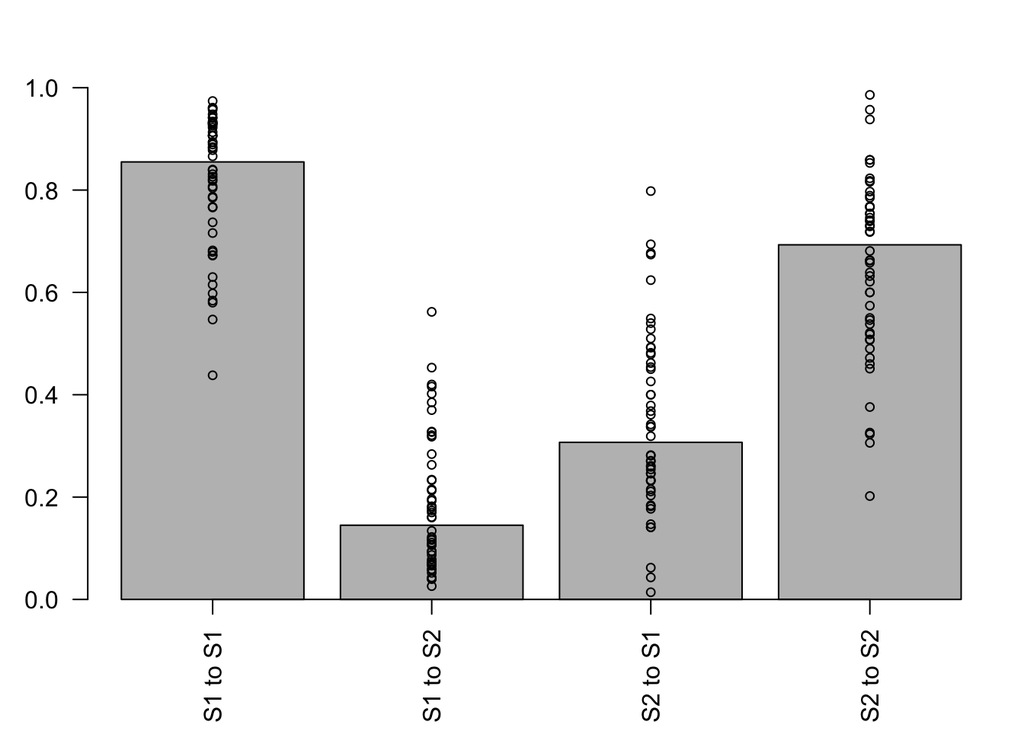

```r
# Transition probabilities of first subject using helper function
PlotTrans(out_2st_emotion,
          subject = 1:50)
```

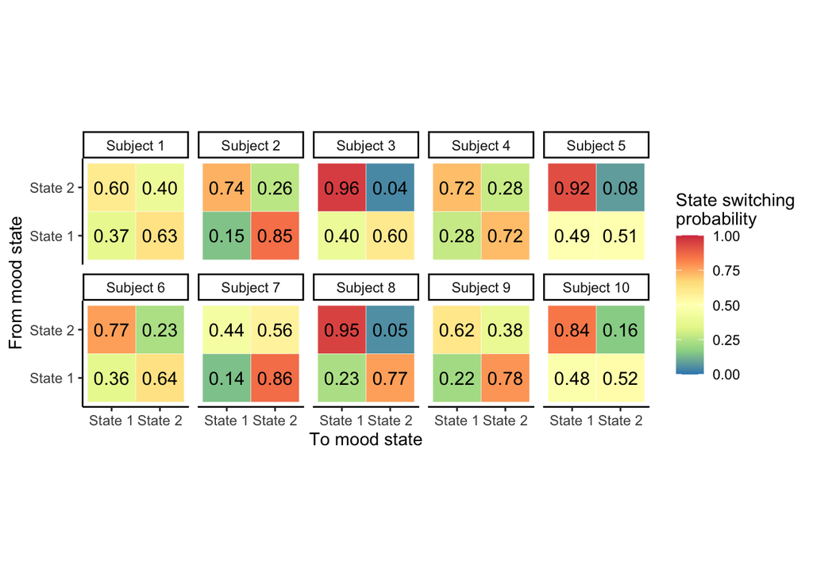

```r
# Transition probabilities of first 10 subjects using ggmHMM function
plot_gamma(out_2st_emotion,
           level = "subject",
           subject = 1:10,
           ncol_facet = 5) # plot with facets
```

**Exercise 6** Interpret the transition probabilities. Is there much heterogeneity between persons? Are subjects generally more likely to stay in the same state, or switch states? What does this mean, if we take the substantive interpretation of the states into account?

Note that for a two-state model, the information given by the transition probabilities is limited; The diagonals inform us about the probability of remaining in a state (and therefore the stability/duration of states), but the off-diagonals do not provide us with unique information; if a subject goes out of the state, they only have one left to go to. A three-state model may have more interesting information to provide. It could tell us, for example, whether a subject is more likely to immediately switch between a ‘positive’ and a ‘negative’ state, or whether they generally move through a ‘medium’ state first.

## Model selection

### Fit models with a plausible number of states

One of the challenges when using hidden Markov models is that in most cases we do not know how many states we should choose and therefore need to learn the number of states from the data. Here, we assume that only a model with 2, 3, or 4 states is plausible and will perform model selection between those models. However, the model selection discussed here naturally extends to any sequence of candidate models.

As checking model fit is discussed at a later point in the practical, we will investigate the different models based on the state composition and the AIC. However, it should be noted that convergence and model fit are important characteristics that should be considered when choosing a model to interpret. The 2-state model was fitted in the first practical, and saved in the object `out_2st_emotion`.

**Exercise 7** To save time we have already pre-run a 3-state and 4-state model. Use the function `readRDS()` to load the fitted models from the files `out_3st_emotion.rds` and `out_4st_emotion.rds`, and save them in the objects `out_3st_emotion` and `out_4st_emotion`. The settings we used are shown below.

```r
out_3st_emotion <- readRDS("./data/out_3st_emotion.rds")
out_4st_emotion <- readRDS("./data/out_4st_emotion.rds")
```

```r
####################
# 3 state model
####################

## general model properties
m <- 3
n_dep <- 4

## starting values for gamma
start_gamma_3st <- matrix(c(0.8, 0.1, 0.1,
                        0.1, 0.8, 0.1,
                        0.1, 0.1, 0.8), byrow = TRUE, ncol = m, nrow = m)

## starting values for the emission distribution
start_emiss_3st <- list(matrix(c(80, 10,                                     # happy
                             50, 10,
                             20, 10), byrow = TRUE, ncol = 2, nrow = m),
                    matrix(c(80, 10,                                     # relaxed
                             50, 10,
                             20, 10), byrow = TRUE, ncol = 2, nrow = m),
                    matrix(c(10,  5,                                     # anxious
                             30, 10,
                             50, 15), byrow = TRUE, ncol = 2, nrow = m),
                    matrix(c(10,  5,                                     # depressed
                             30, 10,
                             50, 15), byrow = TRUE, ncol = 2, nrow = m))

## specifying weakly informative prior for continuous emission distributions
emotion_prior_emiss_3st <- prior_emiss_cont(
  gen = list(m = m, n_dep = n_dep),
  emiss_mu0 = list(matrix(c(80, 50, 20), nrow = 1),  # happy
                   matrix(c(80, 50, 20), nrow = 1),  # relaxed
                   matrix(c(10, 30, 50), nrow = 1),  # anxious
                   matrix(c(10, 30, 50), nrow = 1)),  # depressed
  emiss_K0 = rep(list(1), n_dep),
  emiss_V = rep(list(rep(5^2, m)), n_dep),
  emiss_nu = rep(list(1), n_dep),
  emiss_a0 = rep(list(rep(1.5, m)), n_dep),
  emiss_b0 = rep(list(rep(20, m)), n_dep),
)
```

```r
####################
# 4 state model
####################

## general model properties
m <- 4

## starting values for gamma
start_gamma_4st <- matrix(c(0.7, 0.1, 0.1, 0.1,
                            0.1, 0.7, 0.1, 0.1,
                            0.1, 0.1, 0.7, 0.1,
                            0.1, 0.1, 0.1, 0.7), byrow = TRUE, ncol = m, nrow = m)

## starting values for the emission distribution
start_emiss_4st <- list(matrix(c(80, 10,                                     # happy
                             60, 10,
                             40, 10,
                             20, 10), byrow = TRUE, ncol = 2, nrow = m),
                    matrix(c(80, 10,                                     # relaxed
                             60, 10,
                             40, 10,
                             20, 10), byrow = TRUE, ncol = 2, nrow = m),
                    matrix(c(10,  5,                                     # anxious
                             20, 10,
                             40, 10,
                             60, 10), byrow = TRUE, ncol = 2, nrow = m),
                    matrix(c(10,  5,                                     # depressed
                             20, 10,
                             40, 10,
                             60, 10), byrow = TRUE, ncol = 2, nrow = m))

## specifying weakly informative prior for continuous emission distributions
emotion_prior_emiss_4st <- prior_emiss_cont(
  gen = list(m = m, n_dep = n_dep),
  emiss_mu0 = list(matrix(c(80, 60, 40, 20), nrow = 1),  # happy
                   matrix(c(80, 60, 40, 20), nrow = 1),  # relaxed
                   matrix(c(10, 20, 40, 60), nrow = 1),  # anxious
                   matrix(c(10, 20, 40, 60), nrow = 1)),  # depressed
  emiss_K0 = rep(list(1), n_dep),
  emiss_V = rep(list(rep(5^2, m)), n_dep),
  emiss_nu = rep(list(1), n_dep),
  emiss_a0 = rep(list(rep(1.5, m)), n_dep),
  emiss_b0 = rep(list(rep(20, m)), n_dep),
)
```

```r
# Fitting the 3 state model
m <- 3
set.seed(42)
out_3st_emotion <- mHMM(s_data = emotion_mHMM,
                        data_distr = "continuous",
                        gen = list(m = m, n_dep = n_dep),
                        start_val = c(list(start_gamma_3st), start_emiss_3st),
                        emiss_hyp_prior = emotion_prior_emiss_3st,
                        mcmc = list(J = 500, burn_in = 200))

# Fitting the 4 state model
m <- 4
set.seed(42)
out_4st_emotion <- mHMM(s_data = emotion_mHMM,
                        data_distr = "continuous",
                        gen = list(m = m, n_dep = n_dep),
                        start_val = c(list(start_gamma_4st), start_emiss_4st),
                        emiss_hyp_prior = emotion_prior_emiss_4st,
                        mcmc = list(J = 500, burn_in = 200))
```

**Exercise 8** Inspect the general output of the 3- and 4- state models by using the inbuilt `print()` and `summary()` for objects of class `mHMM` returned by the function `mHMM()`.

```r
# 3 state model
out_3st_emotion
```

```
## Number of subjects: 125
##
## 500 iterations used in the MCMC algorithm with a burn in of 200
## Average Log likelihood over all subjects: -2823.466
## Average AIC over all subjects:  5706.932
## Average AICc over all subjects: 5710.502
##
## Number of states used: 3
##
## Number of dependent variables used: 4
##
## Type of dependent variable(s): continuous
```

```r
summary(out_3st_emotion)
```

```
## State transition probability matrix
##  (at the group level):
##
##              To state 1 To state 2 To state 3
## From state 1      0.864      0.087      0.050
## From state 2      0.314      0.575      0.111
## From state 3      0.193      0.110      0.697
##
##
## Emission distribution ( continuous ) for each of the dependent variables
##  (at the group level):
##
## $happy
##           Mean     SD
## State 1 68.106 14.927
## State 2 50.765 22.294
## State 3 40.561 14.148
##
## $relaxed
##           Mean     SD
## State 1 62.515 20.896
## State 2 45.273 25.916
## State 3 38.207 16.530
##
## $anxious
##           Mean     SD
## State 1  5.357  3.538
## State 2 27.273 26.663
## State 3 23.466 14.509
##
## $depressed
##           Mean     SD
## State 1  9.798  7.566
## State 2 36.392 26.328
## State 3 43.209 18.970
```

```r
# 4 state model
out_4st_emotion
```

```
## Number of subjects: 125
##
## 500 iterations used in the MCMC algorithm with a burn in of 200
## Average Log likelihood over all subjects: -2772.047
## Average AIC over all subjects:  5632.095
## Average AICc over all subjects: 5639.906
##
## Number of states used: 4
##
## Number of dependent variables used: 4
##
## Type of dependent variable(s): continuous
```

```r
summary(out_4st_emotion)
```

```
## State transition probability matrix
##  (at the group level):
##
##              To state 1 To state 2 To state 3 To state 4
## From state 1      0.785      0.145      0.053      0.017
## From state 2      0.234      0.664      0.063      0.038
## From state 3      0.265      0.222      0.449      0.064
## From state 4      0.040      0.179      0.063      0.718
##
##
## Emission distribution ( continuous ) for each of the dependent variables
##  (at the group level):
##
## $happy
##           Mean     SD
## State 1 69.306 14.580
## State 2 55.936 14.678
## State 3 52.343 21.409
## State 4 33.437 13.849
##
## $relaxed
##           Mean     SD
## State 1 63.676 20.775
## State 2 51.315 19.587
## State 3 45.295 25.826
## State 4 32.520 15.771
##
## $anxious
##           Mean     SD
## State 1  2.803  2.512
## State 2 10.563  8.595
## State 3 36.242 28.347
## State 4 27.706 20.357
##
## $depressed
##           Mean     SD
## State 1  6.349  5.129
## State 2 27.410 17.391
## State 3 35.180 26.757
## State 4 52.370 18.392
```

### Inspect the state composition of the fitted models

First, we will investigate the composition of the states, and use this to evaluate whether it seems sensible to add extra states. Especially with multivariate data, inspecting the composition of the states is done most easily visually.

**Exercise 9** Use the function `plot_emiss()` from the *ggmHMM* package to visualize the emission distributions of the three-state and four-state model. Do not plot subject-specific effects. Does it seem to make sense to add extra state(s)?

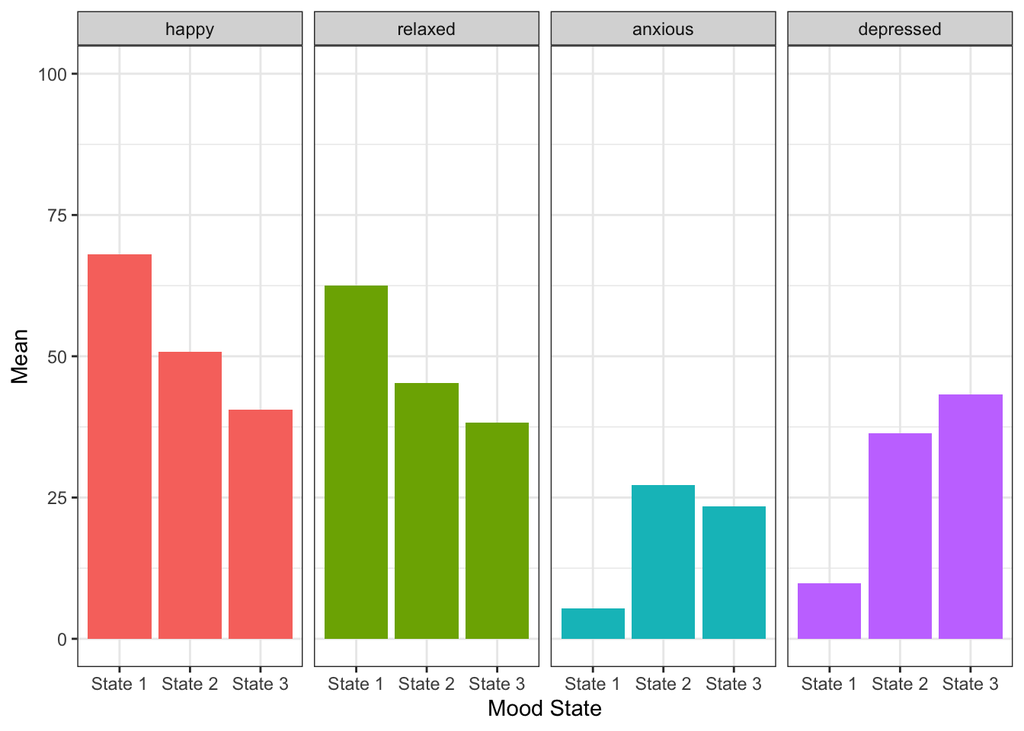

```r
plot_emiss(out_3st_emotion, subject_effects = FALSE) + ylim(c(0,100)) # three-state model with helper function
```

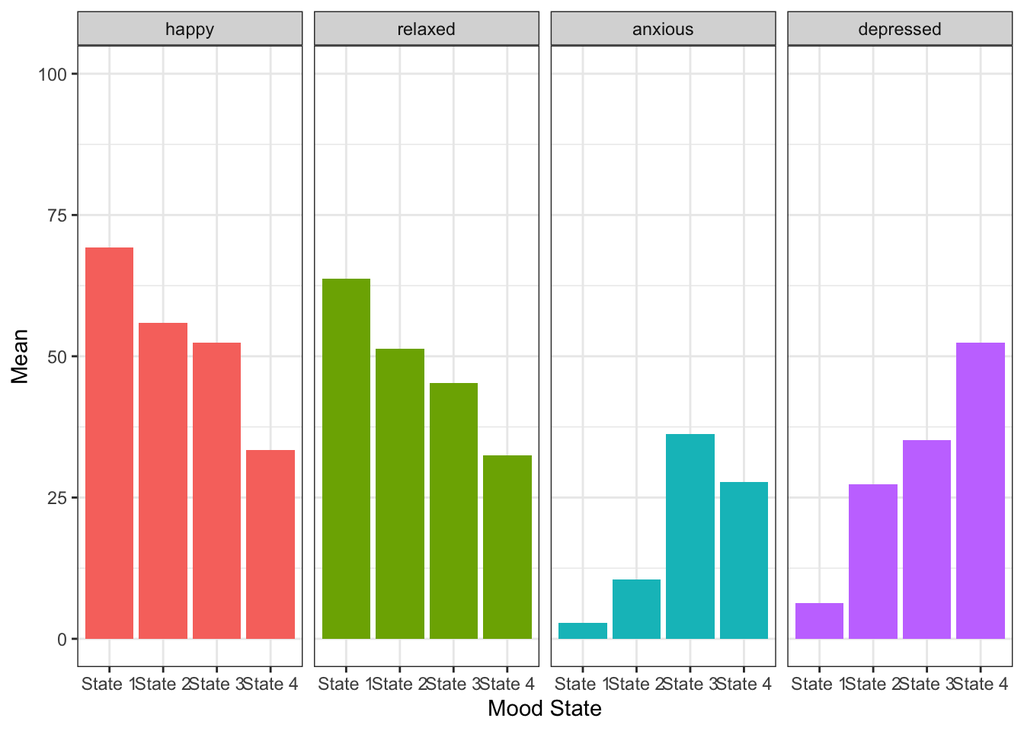

```r
plot_emiss(out_4st_emotion, subject_effects = FALSE) + ylim(c(0,100)) # four-state model with ggmHMM function
```

```r
# Note: the 4th state differentiates the emotions even more.
```

Next, let’s compare the 2-, 3-, and 4-state model on the model selection criterion AIC.

**Exercise 10** Obtain the AIC values of the 2-, 3-, and 4-state model using the `print()` function on the mHMM objects `out_2st_emotion`, `out_3st_emotion`, `out_4st_emotion`, and compare the models. It can be helpful to visualize the AIC values over the states:

```r
out_2st_emotion
```

```
## Number of subjects: 125
##
## 500 iterations used in the MCMC algorithm with a burn in of 200
## Average Log likelihood over all subjects: -2870.816
## Average AIC over all subjects:  5777.631
## Average AICc over all subjects: 5778.915
##
## Number of states used: 2
##
## Number of dependent variables used: 4
##
## Type of dependent variable(s): continuous
```

```r
out_3st_emotion
```

```
## Number of subjects: 125
##
## 500 iterations used in the MCMC algorithm with a burn in of 200
## Average Log likelihood over all subjects: -2823.466
## Average AIC over all subjects:  5706.932
## Average AICc over all subjects: 5710.502
##
## Number of states used: 3
##
## Number of dependent variables used: 4
##
## Type of dependent variable(s): continuous
```

```r
out_4st_emotion
```

```
## Number of subjects: 125
##
## 500 iterations used in the MCMC algorithm with a burn in of 200
## Average Log likelihood over all subjects: -2772.047
## Average AIC over all subjects:  5632.095
## Average AICc over all subjects: 5639.906
##
## Number of states used: 4
##
## Number of dependent variables used: 4
##
## Type of dependent variable(s): continuous
```

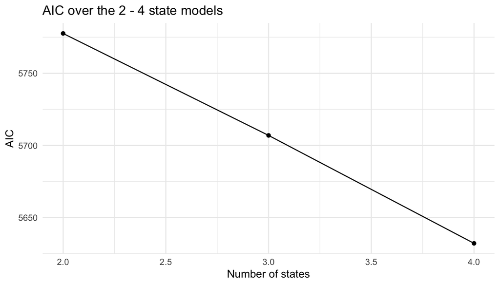

```r
AICs <- data.frame(AIC = c(5777.631, 5706.932, 5632.095),
                   states = c(2:4))
ggplot(AICs, mapping = aes(x = states, y = AIC)) +
  geom_point() +
  geom_line() +
  ggtitle("AIC over the 2 - 4 state models") +
  xlab("Number of states") +
  theme_minimal()
```

Determining the number of states is often not a trivial task and typically involves several considerations (including model fit and fit indices like the AIC) that themselves often depend on the research question at hand.

## Model diagnostics and fit

In this section we will inspect model diagnostics and fit, checking convergence, label switching, using posterior predictive checks (PPCs), and evaluating Pseudo residuals.

### Convergence

Within any Bayesian analysis, convergence needs to be assessed in order to rule out output resulting from a local (instead of global) maximum. To check this, multiple chains (here we will use 2 for simplicity, but we recommend using at least 4) need to be run, performing the same analysis but using (slightly) different starting values in each chain. Note that in multilevel hidden Markov models, it is important to still keep sensible starting values when varying these. For example, when modelling continuous or count data, we need to keep the same sensible ordering of $\bar{\mu}_i$ or $\bar{\lambda}_i$ given data and process. Values of the (weakly informative) prior distributions should be fixed over the chains.

**Exercise 11** Specify new starting values to fit at least one additional chain for the 2 state multilevel HMM model. Do not yet run the model.

**Exercise 12** To save time, we will provide you with an additional chain, run with the starting values below. Use the function `readRDS()` to load the fitted model from the file `out_2st_emotion_b.rds`, and save it in the object `out_2st_emotion_b`.

**Note.** The priors that we used may be slightly different from the ones you specified in your model in the first practical. For now, we will ignore this for simplicity, but it is important to use the same settings for the prior when applying the model yourself.

```r
out_2st_emotion_b <- readRDS("./data/out_2st_emotion_b.rds")
```

```r
m <- 2
n_dep <- 4

start_gamma_b <- matrix(c(0.9, 0.1,
                        0.1, 0.9), byrow = TRUE, ncol = m, nrow = m)

start_emiss_b <- list(matrix(c(80, 10,                                     # happy
                             40, 15), byrow = TRUE, ncol = 2, nrow = m),
                    matrix(c(80, 10,                                     # relaxed
                             40, 15), byrow = TRUE, ncol = 2, nrow = m),
                    matrix(c(5, 5,                                     # anxious
                             30, 15), byrow = TRUE, ncol = 2, nrow = m),
                    matrix(c(5, 5,                                     # depressed
                             30, 15), byrow = TRUE, ncol = 2, nrow = m))
out_2st_emotion_b <- mHMM(s_data = emotion_mHMM,
                        data_distr = "continuous",
                        gen = list(m = m, n_dep = n_dep),
                        start_val = c(list(start_gamma_b), start_emiss_b),
                        emiss_hyp_prior = emotion_prior_emiss,
                        mcmc = list(J = 500, burn_in = 200))
```

Evidence for non convergence can be checked in multiple ways. A first way is, using trace plots which visualize the parameter estimates over the iterations of the MCMC sampler. The chains should not show any trend and good mixing. Furthermore, we should have no label switching (or at least very little) in the subject-specific parameters (see the section ‘label switching’ below).

The trace plots can be obtained using the *ggmHMM* function `plot_trace()`. For now, the following arguments are relevant:

- model: a model or list of models of class `mHMM`
- component: “gamma” for transition probabilities, or “emiss” for emission distributions
- level: “group” for group-level parameters. “subject” for subject-specific parameters.
- vrb: the variable to plot the trace for. For example, “happy” for the happy variable.
- subject: Integer specifying the subject to create trace plots for.

**Exercise 13**

**A.** Use `plot_trace()` to create a trace plot for the group-level transition probabilities of the 2-state model. Use both `out_2st_emotion` and `out_2st_emotion_b`. Hint: you leed to put the models in a list using `list()` to use them in `plot_trace()`.

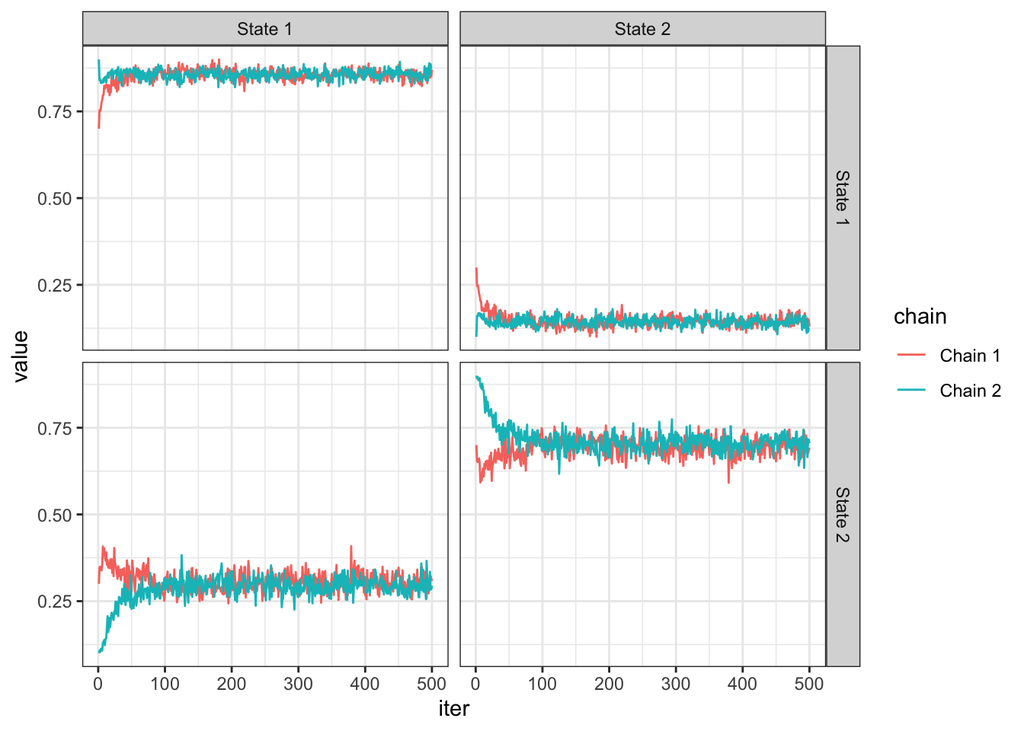

```r
plot_trace(model = list(out_2st_emotion, out_2st_emotion_b),
           component = "gamma",
           level = "group")
```

**B.** In addition to the group level parameters, it is also important to check convergence at the subject level. Use the function `plot_trace()` to create a trace plot for the subject specific emission means of the first subject, for the variable “happy”. Use both `out_2st_emotion` and `out_2st_emotion_b`.

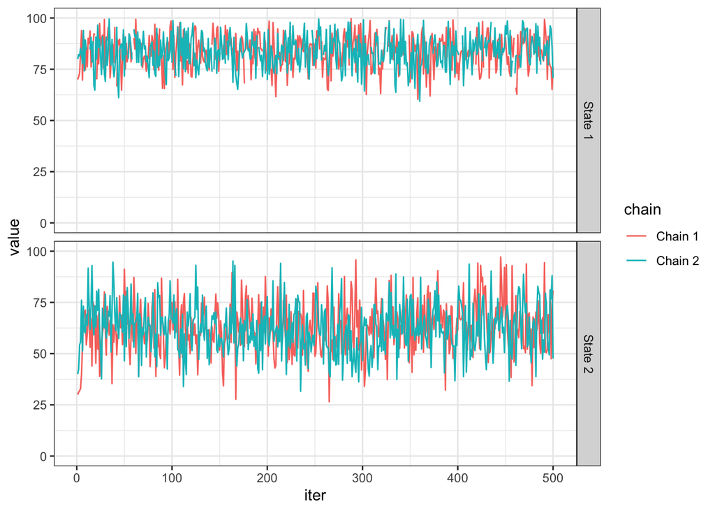

```r
plot_trace(model = list(out_2st_emotion, out_2st_emotion_b),
           component = "emiss",
           level = "subject",
           vrb = "happy",
           subject = 1) + ylim(c(0,100))
```

We should also inspect convergence numerically, with the potential scale reduction factor $\hat{R}$. $\hat{R}$ evaluates equality of means of the different chains - the degree to which variance (of the means) between chains exceeds what one would expect if the chains were identically distributed. A value of R-hat below 1.2 is typically used as a rule of thumb to indicate convergence.

We have provided you with a helper function, `f_GR()`, to calculate the group level $\hat{R}$ values. The function takes the following arguments:

- model_list: a list of models (i.e. multiple chains)
- digits: number of digits to round to. Default is 2.
- burnin: number of burnin iterations to use. Defaults to the number specified when building the first model.

It returns a list with 2 matrices:

- m_RG_gamma is a matrix with m rows and m-1 columns. This is due to the fact that the transition probabilities are estimated using a multinomial logit model, where only m-1 values are estimated (and the last one is derived from the others).
- RG_emiss is a matrix with n_dep rows and m columns. Therefore, the value on the first row and the second column refers to $\hat{R}$ for the first dependent variable (e.g. “happy”) and the second state.

**Exercise 14** Use the function `f_GR()` to calculate the $\hat{R}$ values for the group level transition probabilities and emission distribution means. Did the model reach convergence?

```r
f_GR(model_list = list(out_2st_emotion, out_2st_emotion_b),
      digits = 2,
      burnin = 200)
```

```
## $m_RG_gamma
##      [,1]
## [1,] 1.01
## [2,] 1.06
##
## $RG_emiss
##      [,1] [,2]
## [1,] 1.00 1.01
## [2,] 1.07 1.00
## [3,] 1.01 1.06
## [4,] 1.19 1.14
```

### Label Switching

A concept related to convergence is that of label switching. In a multilevel HMM, it does not matter for the model what the ordering of the states is. For example, a model where State 1 is the ‘positive’ state (e.g. with high “happy” and low “depressed”), and state 2 the ‘negative’ state, or whether it is the other way around. In the iterative MCMC process, the model may switch the labels of the states over iterations, and therefore the interpretation of the states. This is called label switching. In the mHMM, label switching happens at the subject level, but consequently also affects estimates of the group-level effects. It is important to check to what extent this happens.

To check for label switching, inspect trace plots for the subject-level parameters, similar to those from last exercise. Ideally one displayes trace plots from multiple states in a single plot to better see whether the states switch labels. This can be done with the helper function `plot_label_switching()`.

`plot_label_switching()` takes as arguments: * model: output object from `mHMM()` * subject: a vector of integers to select the subjects to create plots for. * vrb: a character vector to specify the variable to plot.

**Exercise 15** Use the function `plot_label_switching()` to evaluate label switching for subject 1 to 5, for the 3-state model. Is there a label switching issue for these persons? And for subjects 6 to 10?

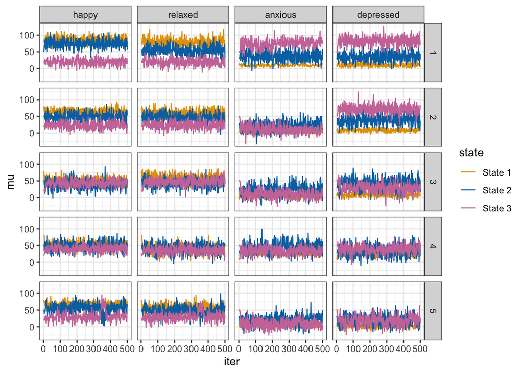

```r
plot_label_switching(out_3st_emotion, subject = 1:5)
```

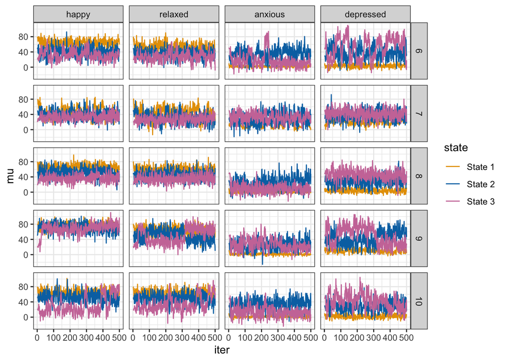

```r
plot_label_switching(out_3st_emotion, subject = 6:10)
```

**Exercise 16** The estimate of subject 9’s state specific means for each variable is calculated by taking the mean (or median) of all sampled values after the specified burnin period. How does the label switching issue affect the estimates of this subject’s state-specific means?

### PPCs

Finally, we will assess whether the model recovers the data correctly with respect to the mean and standard deviation, to reveal potential model misspecification. It is particularly helpful for group-level model evaluation. First, we need to generate simulated data sets based on obtained parameter estimates. The function `sim_mHMM()` can be used to simulate data using a multilevel hidden Markov model. Note that for each simulated dataset, new subject-specific parameters are simulated, but the group-level parameters remain fixed.

The function takes the following arguments (for more detailed information, use `help(sim_mHMM()`):

- n_t: length of observed sequence for each subject
- n: sumber of subjects
- data_distr: string indicating the type of data to simulate. “continuous” in our case.
- gen: list containing the elemens: m (number of hidden states) and n_dep (number of dependent variables)
- gamma: group-level transition probability matrix. It should be an unnamed matrix with m rows and m columns.
- emiss_distr: group-level emission distributions. Specified as a list of matrices, one for each dependent variable. Each matrix should have 2 columns (mean and sd) and m rows (number of states).
- var_gamma: variance of transition probabilities.
- var_emiss: variance of emission probabilities.

**Exercise 17** Use the script below to simulate 100 datasets based on the model parameters of the 2-state multilevel HMM.

```r
n_sim <- 100 # for now, we will use 100 simulated datasets, but feel free to change.
sim_datasets <- vector("list", n_sim)

m <- ...        # specify the number of states
n_dep <- ...    # specify the number of dependent variables used in mHMM()

# calculate variance in emission distribution
sapply(out_2st_emotion$emiss_varmu_bar, apply, 2, mean, na.rm = TRUE)

for(i in 1:n_sim){
  sim_datasets[[i]] <- sim_mHMM(n_t = 240 , # specify the number of beeps per subject
                                n = 125,    # specify the number of subjects
                                data_distr = "continuous",
                                gen = list(m = m, n_dep = n_dep),
                                gamma = ... ,   # specify the obtained transition prob matrix
                                emiss_distr = ... , # specify the emission distribution, see help file
                                var_gamma = 0.01,
                                var_emiss = c(300, 300, 200, 200)
  )
}
```

```r
n_sim <- 100
sim_datasets <- vector("list", n_sim)

m <- 2
n_dep <- 4

# calculate variance in emission distribution
sapply((out_2st_emotion$emiss_varmu_bar), apply, 2, mean, na.rm = TRUE)
```

```
##            happy  relaxed   anxious depressed
## varmu_1 323.8858 349.0863  77.74446  174.3764
## varmu_2 324.4923 271.7051 441.86128  314.2728
```

```r
set.seed(42)
for(i in 1:n_sim){
  sim_datasets[[i]] <- sim_mHMM(n_t = 240,
                                n = 125,
                                data_distr = "continuous",
                                gen = list(m = m, n_dep = n_dep),
                                gamma = unname(obtain_gamma(out_2st_emotion)),
                                emiss_distr = obtain_emiss(out_2st_emotion),
                                var_gamma = 0.01,
                                var_emiss = c(300, 300, 200, 200)
  )
}
```

**Exercise 18** For each simulated data set, calculate the summary statistics of interest for all four variables (i.e., mean and standard deviation).

```r
means_simdata <- matrix(, nrow = n_sim, ncol = n_dep)
for(i in 1:n_sim){
  means_simdata[i,] <- apply(sim_datasets[[i]]$obs[,2:(n_dep + 1)], 2, mean)
}

sd_simdata <- matrix(, nrow = n_sim, ncol = n_dep)
for(i in 1:n_sim){
  sd_simdata[i,] <- sqrt(apply(sim_datasets[[i]]$obs[,2:(n_dep + 1)], 2, var))
}
```

Now that we have simulated datasets and obtained the summary characteristics, we will visually compare the characteristics of the simulated data to that of the observed data.

**Exercise 19** Plot the summary characteristics (mean and sd) of the simulated datasets in histograms, and add a vertical line for the mean and sd in the observed data to aid the comparison.

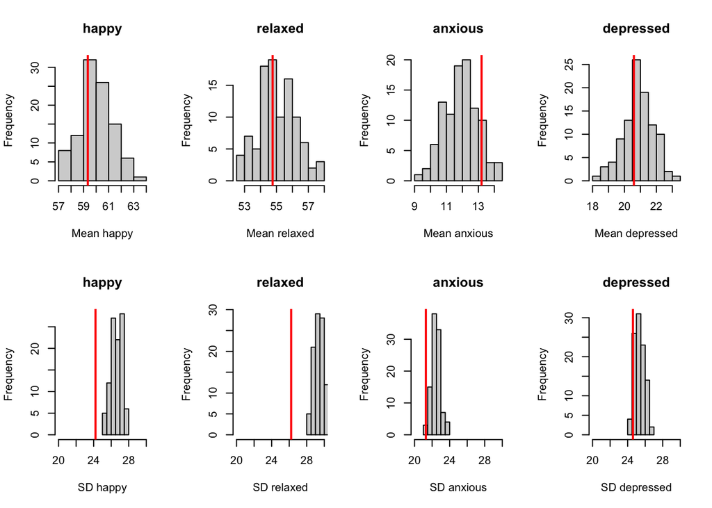

```r
vars <- names(obtain_emiss(out_2st_emotion))

par(mfrow = c(2,4))
for(i in 1:n_dep){
  hist(means_simdata[,i],
       main = vars[i],
       xlab = paste("Mean", vars[i])
  )
  abline(col = "red", lwd = 2, v = mean(emotion_mHMM[,1+i], na.rm = TRUE))
}

# plot histogram sd simulated data and observed in real data
for(i in 1:n_dep){
  hist(sd_simdata[,i],
       main = vars[i],
       xlab = paste("SD", vars[i]),
       xlim = c(20,30)
  )
  abline(col = "red", lwd = 2, v = sqrt(var(emotion_mHMM[,1+i], na.rm = TRUE)))
}
```

```r
# The means show no evidence of bad model fit, however the standard deviations of the simulated datasets are higher compared to the observed data, especially for happy and relaxed. It would be interesting to see whether a 3-state model would partly solve this.
```

### Pseudoresiduals

Where PPCs are most useful for group-level model evaluation, pseudoresiduals are most useful for model evaluation at the subject level. These are residuals that are obtained based on the most likely state sequence for each person (hence the suffix `pseudo`), using the Viterbi algorithm (see previous practical).

We can compute the Root-Mean-Squared-Error (RMSE) of the pseudoresiduals, which is a measure of how well the model fits the data, where a lower RMSE indicates a better fit. This is especially useful to compare models.

We have provided you with two helper functions for this. `GetResid()` can be used to obtain residuals for a specific person for a specific variable. The function takes the following arguments:

- data: the dataset used to build the model
- model: the fitted model
- vrb: string specifying the variable obtain pseudoresiduals for
- subject: integer specifying the subject to obtain pseudoresiduals for

It outputs a list with 4 elements:

- emp: the data of the subject for the variable ‘vrb’
- model: the predicted values of the subject for the variable ‘vrb’
- resid: the pseudoresiduals of the subject for the variable ‘vrb’
- RMSE: the RMSE for the subject for the variable ‘vrb’

**Exercise 20**

**A.** Use `GetResid()` to obtain pseudoresiduals for subject 1 for all variables. Do this for both the 2-state and 3-state model. Hint: use the function `lapply()` to loop over the variables.

```r
pseudoresid_2st <- lapply(c("happy", "relaxed", "anxious", "depressed"), # for variable 1 to 4
                          function(j) GetResid(data = emotion_mHMM, model = out_2st_emotion, vrb = j, subject = 1))
pseudoresid_3st <- lapply(c("happy", "relaxed", "anxious", "depressed"), # for variable 1 to 4
                          function(j) GetResid(data = emotion_mHMM, model = out_3st_emotion, vrb = j, subject = 1))
```

**B.** Obtain the RMSE for the pseudoresiduals of subject 1 for all variables, and compare the RMSE of the 2-state and 3-state model. Which model fits better for this person?

```r
RMSE_2st <- sapply(pseudoresid_2st, function(x) x$RMSE)
RMSE_3st <- sapply(pseudoresid_3st, function(x) x$RMSE)
print(RMSE_2st)
```

```
## [1] 20.04446 22.32644 24.64004 22.43806
```

```r
print(RMSE_3st)
```

```
## [1] 14.58216 21.99121 24.38652 20.12457
```

```r
## The 3-state model has slightly better fit for subject 1 as it has the lowest RMSE for all variables.
```

After obtaining the pseudoresiduals, we can also plot them separately for each person and each variable to assess: 1. Whether the pseudoresiduals are (roughly) normally. 2. Whether there is a trend over time. 2. Whether there is any remaining dependency between residuals over time (can also be assessed using the autocorrelation). 3. Whether there are any outliers. 4. Whether variance is (roughly) stable over time.

We have provided you with a helper function, `PlotResid()`, to plot the pseudoresiduals. Visually inspecting the predictions vs. the respective empirical data and the residuals is useful because it allows us not only to judge how well the model predicts, but also in which way predictions fail. This, in turn, may allow us to improve the model or at least draw the correct conclusions from the current model.

`PlotResid()` takes the following arguments:

- model: output model from `mHMM()`
- data: a data frame used to build the model.
- vrb: character string specifying the variable to plot pseudoresiduals for
- subject: vector of subjects to plot pseudoresiduals for.

**Exercise 21** Use `PlotRes()` to plot the pseudoresiduals for subject 1 to 3 to for the variable `happy`, for the 3-state model. How do you evaluate the model fit for these subjects?

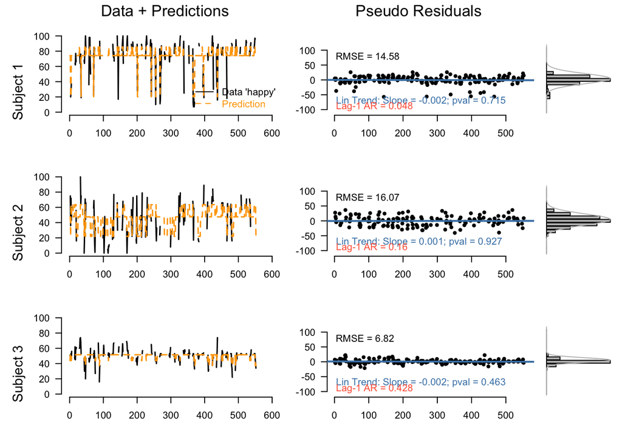

```r
PlotRes(out_3st_emotion,
         data = emotion_mHMM,
         vrb = "happy",
         subject = 1:3)
```